# Шаблон для выполнения заданий лабораторной работы 1. Вариант 2_4.

**Внимание!** Прежде, чем приступать к выполнению заданий, следует переименовать этот файл. В названии файла обязательно должна присутствовать фамилия студента - автора решения.

**За безымянные работы рейтинговые баллы начислены не будут!**

Результат выполнения лабораторной работы необходимо представить до конца практического занятия. Формат представления результата - ответ на задание в LMS в виде двух файлов:

- ноутбук в формате ipynb, содержащий программный код, результаты его выполнения, а также все необходимые пояснения и комментарии (в текстовых ячейках);
- файл в формате html, полученный путем экспорта ноутбука из п. 1).

Правильность работы представленного программного кода контролируется с помощью вопросов теста, ответы на которые также необходимо представить до конца практического занятия.

Критерии оценивания выполненной работы:

1. Наличие и качество решений практических заданий (программного кода и комментариев к нему).
2. Количество правильных ответов на вопросы проверочного теста.

**Внимание:** самостоятельное и вдумчивое выполнение заданий повышает вероятность успешного прохождения итогового теста по теме 1 на следующей учебной встрече (будет проверяться понимание работы принципов работы с инструментарием и, в частности, умение понимать программный код).

### Задание 1

Выполнить импорт библиотеки NumPy и модуля Pyplot библиотеки Matplotlib.

Подключить "построение графиков online"

```python
# Ваш код
import numpy as np
import matplotlib.pyplot as plt
%matplotlib inline
```

### Задание 2

Создать список sp, выполнив код в ячейке ниже

```python
np.random.seed(8)
sp = [[round(np.random.rand(), 4) for j in range(2, 9)] for i in np.linspace(2, 46, 11)]
```

Преобразовать список sp в массив matr

```python
# Раскомментировать строку ниже и дописать определение массива

matr = np.array(sp)
```

Вывести размерность полученного массива (число строк и столбцов)

```python
# Ваш код
print("Размерность массива matr:", matr.shape)
```

```
Размерность массива matr: (11, 7)
```

Вывести элемент, стоящий в третьем (по порядку, а не по индексу) столбце последней строки полученного массива

```python
# Ваш код
print("Элемент в 3-м столбце последней строки:", matr[-1, 2])
```

```
Элемент в 3-м столбце последней строки: 0.3064
```

### Задание 3

Создать массив fexp, содержащий значения функции $\; f(x) = e^{3x+1} $

для значений $x$, принадлежащих отрезку [-0.12; 0.51] с шагом 0.03.

```python
# Ваш код
x = np.arange(-0.12, 0.51 + 0.03, 0.03)
fexp = np.exp(3*x + 1)
```

Вывести значение fexp[12], округленное до 3 знаков после запятой.

```python
# Ваш код

print("fexp[12] =", round(fexp[12], 3))
```

```
fexp[12] = 5.585
```

### Задание 4

Создать массивы D1 и M2, выполнив код в ячейке ниже

```python
np.random.seed(8)
D1 = np.random.rand(24)
M2 = np.random.rand(3, 7)
```

Вывести элементы массивов (для контроля)

```python
# Ваш код
print("D1:", D1)
print("M2:", M2)
```

```
D1: [0.8734294  0.96854066 0.86919454 0.53085569 0.23272833 0.0113988
 0.43046882 0.40235136 0.52267467 0.4783918  0.55535647 0.54338602
 0.76089558 0.71237457 0.6196821  0.42609177 0.28907503 0.97385524
 0.33377405 0.21880106 0.06580839 0.98287055 0.12785571 0.32213079]
M2: [[0.07094284 0.22476994 0.39363491 0.896145   0.34546161 0.98474944
  0.02873205]
 [0.35168474 0.38095889 0.76416013 0.93880391 0.3196898  0.43247593
  0.27014574]
 [0.80105589 0.63823881 0.06869013 0.60364448 0.79557456 0.03200816
  0.45544782]]
```

Преобразовать размерность массива D1 так, чтобы этот массив состоял из 8 строк.

```python
# Ваш код
D1 = D1.reshape(8, 3)
```

Найти матричное произведение D1 и M2, результат сохранить в массиве DM

```python
# Ваш код
DM = np.dot(D1, M2)
```

Вывести последний элемент предпоследней строки матрицы DM. Значение округлить до 2 знаков после запятой.

```python
# Ваш код
print("Последний элемент предпоследней строки DM:", round(DM[-2, -1], 2))
```

```
Последний элемент предпоследней строки DM: 0.1
```

### Задание 5

Преобразовать матрицу DM, созданную в задании 4, в одномерный вектор DM_vec и вывести элемент DM_vec[9] с точностью до 3 знаков после запятой.

```python
# Ваш код
DM_vec = DM.flatten()
print("DM_vec[9] =", round(DM_vec[9], 3))
```

```
DM_vec[9] = 0.388
```

Для матрицы DM, созданной в задании 4, сохранить в массиве sDM элементы строк с четными индексами, стоящие в первых трех столбцах.

Операцию выполнить, используя инструменты работы с массивами (без применения циклов и списков)

```python
# Ваш код
sDM = DM[::2, :3]
print("sDM:\n", sDM)
```

```
sDM:
 [[1.09885794 1.12004853 1.14363756]
 [0.59073114 0.58362704 0.51281102]
 [0.80091135 0.83791704 0.88644936]
 [0.15334407 0.20037805 0.30310455]]
```

### Задание 6

К матрице sDM, созданной в задании 5, добавить столбец, состоящий из единиц. Добавляемый столбец вставить в конце (последним столбцом).

Результат сохранить в массиве sDM1.

```python
# Ваш код
# Задание 6: Добавление столбца из единиц и вычисление определителя
# Создаем столбец из единиц
ones_col = np.ones((sDM.shape[0], 1))

sDM1 = np.hstack((sDM, ones_col))
print("sDM1:\n", sDM1)

det_sDM1 = np.linalg.det(sDM1)
```

```
sDM1:
 [[1.09885794 1.12004853 1.14363756 1.        ]
 [0.59073114 0.58362704 0.51281102 1.        ]
 [0.80091135 0.83791704 0.88644936 1.        ]
 [0.15334407 0.20037805 0.30310455 1.        ]]
```

Вычислить определитель матрицы sDM1.

Вывести его значение с точностью до 3 знаков после запятой

```python
# Ваш код
print("Определитель sDM1 =", round(det_sDM1, 3))
```

```
Определитель sDM1 = 0.001
```

### Задание 7

Добавить к матрице sDM1, созданной в задании 6, строку, содержащую минимальные элементы элементы соответствующих столбцов sDM1. Добавляемую строку вставить в начале (первой строкой).

Результат сохранить в массиве sDM1min.

```python
# Ваш код
min_row = np.min(sDM1, axis=0)

sDM1min = np.vstack((min_row, sDM1))
print("sDM1min:\n", sDM1min)
```

```
sDM1min:
 [[0.15334407 0.20037805 0.30310455 1.        ]
 [1.09885794 1.12004853 1.14363756 1.        ]
 [0.59073114 0.58362704 0.51281102 1.        ]
 [0.80091135 0.83791704 0.88644936 1.        ]
 [0.15334407 0.20037805 0.30310455 1.        ]]
```

Вывести элемент матрицы sDM1min, стоящий в первой (по порядку, а не по индексу) строке и в третьем (по порядку) столбце. Значение округлить до 3 знаков после запятой.

```python
# Ваш код
print("Элемент в 1-й строке, 3-м столбце sDM1min:", round(sDM1min[0, 2], 3))
```

```
Элемент в 1-й строке, 3-м столбце sDM1min: 0.303
```

Вывести размерность массива sDM1min.

```python
# Ваш код
# Вывод размерности массива
print("Размерность sDM1min:", sDM1min.shape)
```

```
Размерность sDM1min: (5, 4)
```

### Задание 8

Построить график функции $$f(x) = \frac{2x-1}{(x-1)^2}$$ на отрезке [-1, 0.4] c шагом, равным 0.05.

Выставить метки по осям: по оси абсцисс с шагом 0.2; по оси ординат - с шагом 0.1.

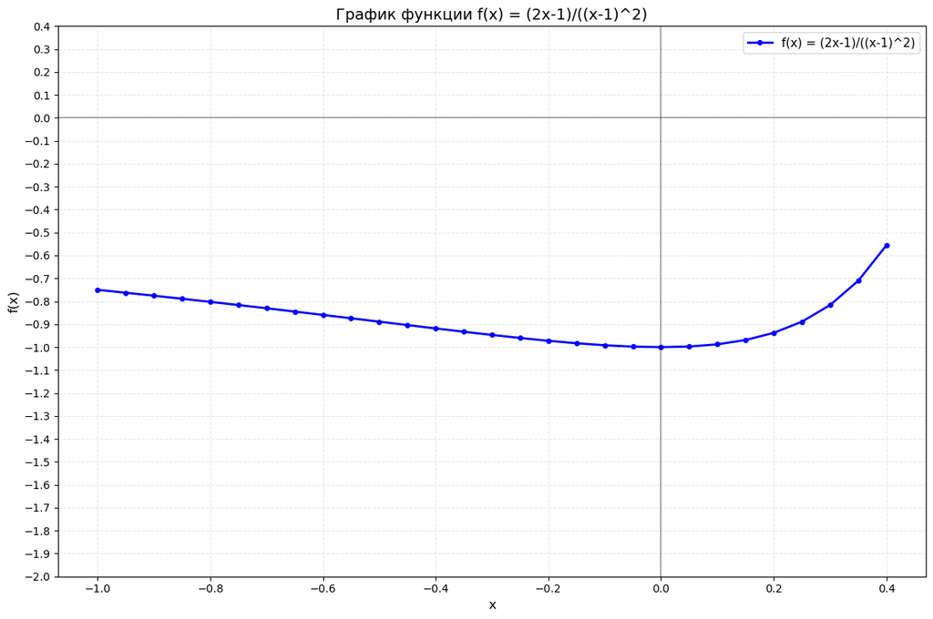

```
Локальный минимум функции:
x = 0.00
f(x) = -1.000
Ордината точки локального минимума: -1.000
```

```python
# Создаем массив x от -1 до 0.4 с шагом 0.05
x = np.arange(-1, 0.4 + 0.05, 0.05)

# Вычисляем значения функции f(x) = (2x-1)/((x-1)^2)
# Используем .T для корректных вычислений
f = (2*x - 1) / ((x - 1)**2)

# Построение графика
plt.figure(figsize=(12, 8))
plt.plot(x, f, 'b-', linewidth=2, marker='o', markersize=4, label='f(x) = (2x-1)/((x-1)^2)')

# Настройка меток по осям
plt.xticks(np.arange(-1, 0.5, 0.2))
plt.yticks(np.arange(-2, 0.5, 0.1))

# Добавление сетки, легенды и подписей
plt.grid(True, alpha=0.3, linestyle='--')
plt.xlabel('x', fontsize=12)
plt.ylabel('f(x)', fontsize=12)
plt.title('График функции f(x) = (2x-1)/((x-1)^2)', fontsize=14)
plt.legend(fontsize=11)

# Добавляем горизонтальную и вертикальную линии для наглядности
plt.axhline(y=0, color='k', linestyle='-', alpha=0.3)
plt.axvline(x=0, color='k', linestyle='-', alpha=0.3)

# Отображение графика
plt.tight_layout()
plt.show()

# Определение ординаты точки локального минимума
min_index = np.argmin(f)
print(f"Локальный минимум функции:")
print(f"x = {x[min_index]:.2f}")
print(f"f(x) = {f[min_index]:.3f}")
print(f"Ордината точки локального минимума: {f[min_index]:.3f}")
```

Определить по графику ординату точки локального минимума функции